# Feasibility of ammonia-aqua chiller

Contents

# Feasibility of ammonia-aqua chiller

```python
%%html
<img src="../img/Diagram_for_ammonia.svg">
<img src="./img/Diagram_for_ammonia.svg">
```

[figure not shown]

## Definitions

- $T_{evap}$ : temperature at evaporator outlet (point 13)
- $T_{cond}$ : temperature at condenser outlet (point 10)
- $T_{abs}$ : Temperature at absorber liquid outlet (point 1)
- $T_{gen}$ : Temperature at generator liquid outlet (point 4)
- $T_{rect}$ : Temperature at rectifier vapor outlet (point 9)
- $x_{refrig}$ : The ammonia mass fraction in the refrigerant stream (points 9, 10, 11, 12, 13, 14)
- $x_{rich}$ : The ammonia mass fraction in the rich stream (points 1, 2, 3, 3')
- $x_{weak}$ : The ammonia mass fraction in the weak stream (points 4, 5, 6)
- $Qu_{evap}$ : the vapor quality at the evaporator outlet (point 13) (typically less than 1 because there is some water in the refrigerant)

### Generator/desorber

- Assumptions are designed to give the "best case" of performance.
- Assumption: vapor produced in the desorber is everywhere locally in equilibrium with the liquid.
- Assumption: vapor flows counter to liquid, ie. from near point 4 toward point 3', so all vapor going to rectifier comes from near point 3'. This assumption affects the computation of the heat vs temperature demand curve in the desorber HX.
- Point 3 : Rich stream entering desorber, typically subcooled.
- Point 3' : The point in the rich stream where external heating brings it to saturated state (Qu=0).
- Unnamed point : The vapor stream
- Point 8 : The vapor stream leaving the desorber and entering the rectifier.
- Point 7 : The reflux (liquid) returned from the rectifier to the desorber.

### Rectifier:

- Assumptions are designed to give the best case of performance, equivalent to design with infinite number of plates and size.
- Assumption: liquid formed is everywhere locally in equilibrium with vapor, and flowing counter to it. This assumption affects the computation of the heat vs temperature demand curve.
- Vapor stream starts at point 8 and exits at point 9.
- Liquid stream starts at (unnamed point in equilibrium with point 9) and exits at point 7.

### Absorber:

- Assumption : vapor absorbed is everywhere locally in equilibrium with liquid (or absorbs into subcooled liquid with no resistance) and flowing counter to it.
- Point 1 : Liquid outlet at equilibrium with refrigerant vapor inlet (point 14).
- Assumption : Computation of the heat rejection demand vs temperature curve in the absorber stream (for HX calculations) depends on the weak stream inlet state (point 6) as follows:
  - If it is subcooled, then there is an imagined segment of the process near the weak inlet where the liquid stream absorbs refrigerant without any demand for heat rejection, until the liquid stream reaches saturation and equilibrium.
  - Saturated liquid : The vapor-liquid interface extends through the entire absorber. Absorbing an incremental amount of vapor requires an amount of heat rejection depending on the local equilibrium state and mass flow rates of liquid and vapor.
  - Partially vapor : there is an imagined segment of the absorber near the weak stream inlet where the weak stream just rejects heat via the HX and does not absorb any vapor. Throughout that process, the liquid and vapor are in equilibrium and are represented by one state with the mass fraction of the weak stream. Upon reaching a saturated liquid state, the weak stream enters the main segment of the absorber and begins to absorb from the refrigerant stream.
  - All vapor : there is clearly a problem with the design. But nevertheless, I cool the weak stream all the way to saturated liquid state, just as for partial vapor at inlet.

### Other assumptions

- For purpose of this feasibility question, neglect friction losses and resulting pressure changes.

## Constraints

There are some necessary conditions for the chiller to produce refrigerant flow. I'll try to write these as inequalities, so that we can develop constraint functions that can be used in a solver or optimizer. Drawing a cycle may be feasible for cases with equality, but to actually produce cooling and compute positive mass flow, the inequalities must hold strictly.

### Initial inputs

We assume that $Qu_{evap}$, $x_{refrig}$, $T_{evap}$, and $T_{cond}$ are given. Clearly, we must require that

- $T_{evap} \le T_{cond}$
- $T_{cond}$ less that critical temperature at x_refrig
- $T_{evap}$ greater than freezing temperature at x_refrig

Then we'll compute $P_{evap}$ and $P_{cond}$ from the other inputs.

### Absorber

This is the heart of the cooling cycle, as the absorber is the component that draws a low pressure on the evaporator. At first look, we can constrain the total pressure: $P_{vapor,absorber} \le P_{evap}$. That is,

- $P(T=T_{abs}, x=x_{rich}, Qu=0) \le P_{evap}$

Since the state function is monotonic and increasing wrt. T and x inputs (decreasing wrt. Qu), we could try re-writing alternate forms:

- $ x_{rich,max} := x(T=T_{abs}, P=P_{evap}, Qu=0) \ge x_{rich} $
- $ T(P=P_{evap}, x=x_{rich}, Qu=0) \ge T_{abs} $
- $ Qu(T=T_{abs}, P=P_{evap}, x=x_{rich}) \le 0 $

Since we have not previously determined $x_{rich}$, we can use the constraint limiting it to define $x_{rich,max}$.

Note that the refrigerant vapor coming into the absorber will not be in equilibrium with the rich liquid. This may be considered a loss mechanism intrinsic to the absorption cycle. A restriction more specific than the one above is that partial pressures of both species be less than the partial pressures in the vapor state in equilibrium with the rich saturated liquid (the same total pressure as the vapor state). Using $\bar{x}$ for molar fraction, we have

- Ammonia: $ \bar{x}_{rich} P(T=T_{abs}, x=x_{rich}, Qu=0) \le \bar{x}_{refrig} P_{evap}$
- Water: $ (1-\bar{x}_{rich}) P(T=T_{abs}, x=x_{rich}, Qu=0) \le (1- \bar{x}_{refrig}) P_{evap}$

Typically, $\bar{x}_{rich}$ is on the order of 0.5, whereas $(1-\bar{x}_{refrig})$ is on the order of 0.001 or less. So the constraint on the water vapor pressure is the stricter one; but it turns out that temperatures required to absorb such low pressure water vapor are much too low, so likely all water in the refrigerant stream must be pumped out of the evaporator. Taking $x_{rich}$ as given, we can put the ammonia absorption constraint in terms of $T_{abs}$, as follows. First, define

$$ P_{abs}(x_{rich}) = \frac{\bar{x}_{refrig}}{\bar{x}_{rich}} P_{evap} $$

Now we have

- $ T(P=P_{abs}(x_{rich}), x=x_{rich}, Qu=0) \ge T_{abs} $

or in other words

$$ T_{abs,max}(x_{rich}) := T(P=P_{abs}(x_{rich}), x=x_{rich}, Qu=0) $$

The saturation function on the right is decreasing wrt. $x_{rich}$ and increasing wrt. $P_{abs}$, which in turn is decreasing in $x_{rich}$; so all together $T_{abs,max}$ is decreasing. (Below, the function is explored numerically.) Thus

\begin{align} T_{abs} &\le T_{abs,max}(x_{rich,max}) \\ & \le T_{abs,max}(x_{rich}) \end{align}

The first inequality is sufficient to gaurantee feasible operation of the absorber, although not necessary. In a real system, mass flow resistance will prevent $x_{rich}$ from reaching its maximum, in which case the upper limit on $T_{abs}$ (favorably) increases; this would have an unfavorable effect on the temperature required in the generator, which will be seen in the next section.

### Generator

For the generator to produce vapor, we merely need it to heat the inlet stream beyond saturation. (We place no requirement on the mass fraction of the vapor coming off, since the rectifier will control what is ultimately delivered as refrigerant.) So to start, we can write the constraint:

- $ Qu(T=T_{gen}, P=P_{cond}, x=x_{rich}) \ge 0 $, with alternate forms:
  - $ x(...) \le x_{rich}$
  - $ P(...) \ge P_{cond}$
  - $ T(...) \le T_{gen}$

Although we have not previously fixed the rich stream ammonia mass fraction, $x_{rich}$, we do have a constraint on that resulting from the constraints on the absorber:

$$ x_{rich} \le x_{rich,max} $$

Via the transitive property, this relation together with the appropriate form of the constraint gives:

- $ x(T=T_{gen}, P=P_{cond}, Qu=0) \le x(T=T_{abs}, P=P_{evap}, Qu=0) $

The right hand side may be called $x_{rich,max}$, so all the alternate versions of this constraint are:

- $ x(T=T_{gen}, P=P_{cond}, Qu=0) \le x_{rich,max} $
- $ P(T=T_{gen}, x=x_{rich,max}, Qu=0) \ge P_{cond} $
- $ T(x=x_{rich,max}, P=P_{cond}, Qu=0) \le T_{gen} $
- $ Qu(T=T_{gen}, P=P_{cond}, x=x_{rich,max}) \ge 0 $

We should note that this new inequality is necessary to guarantee vapor formation, but since we dropped the intermediate inequality, it is worthwhile to ask whether it is sufficient. Well, as more refrigerant flows, $x_{rich}$ must drop below $x_{rich,max}$ (to be able to pick up a larger ammonia mass) and this pushes up the lower limit on $T_{gen}$. However, in the limiting case as refrigerant flow drops to zero (for fixed rich solution flow), $x_{rich}$ and $x_{weak}$ converge. Considering the supply heat demand, a goal of keeping $T_{gen}$ to a minimum favors that the ammonia solution be rich as possible. Considering the heat reject load, a goal of keeping $T_{abs}$ to a maximum favors that the ammonia solution be as weak as possible. So the absorber and desorber are in disagreement; but for a barely feasible case, we can use $x_{rich,max}$.

### Rectifier

The rectifier must cool and purify the ammonia content of the vapor stream to $x_{refrig}$. However, once having determined the condenser pressure, the final extent of the process, assuming equilibrium, could be specified by either $x_{refrig}$ or $T_{rect}$. But in the previous constraints we already assumed that $x_{refrig}$ was used to determine pressure levels, so here let's just constrain $T_{rect}$ this way:

- $x_{refrig} \le x(T=T_{rect}, P=P_{cond}, Qu = 1)$
- $T_{rect} \le T(P=P_{cond}, x=x_{refrig}, Qu = 1)$

In this case, the system can produce positive cooling even when strict equality holds, so we can justify throwing away the $T_{rect}$ as an unnecessary input.

## Implementation

### Desired behavior

The main reason we need to implement these constraints as functions is to help optimizers avoid infeasible domains. However, "avoid" is not yet clearly defined, and depends on the behavior of the optimizer.

1. If we have an optimizer that strictly obeys constraints (ie. does not evaulate the objective outside the feasible domain), then we need only define the behavior of constraint functions in the feasible domain.
2. If we have an optimizer that does not strictly obey constraints, we need to extend the definition of the constraint and objective functions to guarantee that the optimizer will not receive an exception and quit.

The possibility of using a good, unconstrained optimizer is motivation for exploring case 2, but even some optimizers that accept constraints will need to evaluate those constraints at points slightly outside the feasible domain. Some of the constraint functions require property lookups that can fail by exception; in that case, a typical strategy is to return an arbitrary large cost for the constraint. Using an infinite cost results in bad behavior for gradient-based methods, but even with finite values the constraints are still discontinuous. So, can we extend the definition of the constraint and objective functions, and how? This "patching" should be continuous and create costs increasing outside the feasible domain. For a model as simple as this single-effect chiller, we know the boundaries of feasibility (per the above derivations). So considerably, we could map any infeasible input point to a feasible point on the boundary. The first trick would be to make the mapping continuous. Secondly, we still need at least one of the constraints to show an increasing cost. Indeed the following method allows us to extend the definitions of the constraint functions.

- We define the constraints in terms of upper and lower bounds on input variables as functions of other variables.
- We evaluate the constraints in a sequence. When a constraint does not hold, we *override* the value of the relavent input for successive evaluations.
- For that, we preserve the original input variable for comparison to the derived boundary for that variable.

It appears that this works for the present model because the model is solved fairly explicitly (without iteration and circular dependence) and because there is a sequence of constraints for which evaluation of the first boundary is guaranteed, and successive boundaries depend only on variables that are already constrained. In more general cases, here are some suggestions:

1. Attempt to apply the override method, using sequential evaluation of constraints and adjustment of input variables.
2. If that method does not work, insert a meta-model between the model and the optimizer to catch exceptions from infeasible inputs. The meta-model must do two things: for infeasible inputs, catch the exception and return a high cost. Meanwhile, it must collect all the points visited by the optimizer and classify them as feasible/infeasible, and use the data to develop via regression a constraint function that fits the infeasible domain and has properties that encourage convergence back to the feasible domain.
3. Alternatively, if there is way to define a continuous mapping into the feasible domain (eg. by a backtracking linesearch to the boundary), the meta-model could apply this mapping.

The question remains whether there are generic or universal algorithms for other types of models.

### Code

Note that the above derivations make use of the molar fraction, $\bar{x}$, but some of the implementation functions use mass basis.

```python
import CoolProp.CoolProp as CP
from ammonia_props import massFractionToMolar, AmmoniaProps
import ammonia1
amm=ammonia1.amm
import numpy
from numpy import array, nan, inf
import matplotlib.pyplot as plt
```

```python
import ammonia_props
ammonia_props.availableCodeStringsForward
```

```
{123: ['T', 'P', 'x'],
 128: ['T', 'P', 'Qu'],
 137: ['T', 'x', 'v'],
 138: ['T', 'x', 'Qu'],
 148: ['T', 'h', 'Qu'],
 158: ['T', 's', 'Qu'],
 168: ['T', 'u', 'Qu'],
 178: ['T', 'v', 'Qu'],
 234: ['P', 'x', 'h'],
 235: ['P', 'x', 's'],
 238: ['P', 'x', 'Qu'],
 248: ['P', 'h', 'Qu'],
 258: ['P', 's', 'Qu'],
 268: ['P', 'u', 'Qu'],
 278: ['P', 'v', 'Qu']}
```

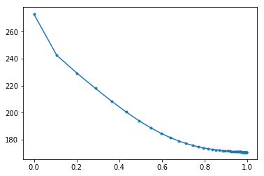

```python
p_min = 0.006 # (bar) -- refer to benchmark_nh3h2o.ipynb
astate = amm.props2(P=p_min,x=0.998,Qu=0)
astate
import numpy
x_refrig = 1-numpy.logspace(0,-8,base=2)
T_min_cond = amm.props2v(P=p_min,x=x_refrig,Qu=0)[0]
import matplotlib.pyplot as plt
plt.plot(x_refrig, T_min_cond,'.-')
plt.show()
```

### Absorber maximum allowed outlet temperature

```python
# Absorber: plotting T_abs,max vs x_rich to find maximum
def P_abs_water(x_rich,x_refrig,P_evap):
    x_molar_rich = massFractionToMolar(x_rich)
    x_molar_refrig = massFractionToMolar(x_refrig)
    alpha = (1 - x_molar_refrig) / (1 - x_molar_rich)
    result = alpha * P_evap
    return result

def P_abs_ammonia(x_rich,x_refrig,P_evap):
    x_molar_rich = massFractionToMolar(x_rich)
    x_molar_refrig = massFractionToMolar(x_refrig)
    #alpha = (1 - x_molar_refrig) / (1 - x_molar_rich)
    alpha = (x_molar_refrig) / (x_molar_rich)
    result = alpha * P_evap
    return result

def T_abs_max_func(x_rich,P_abs):
    return amm.props2(x=x_rich,P=P_abs,Qu=0,out='T')
```

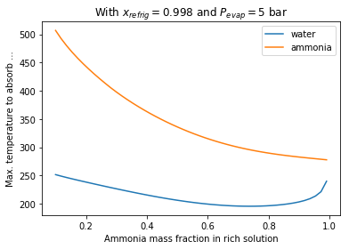

```python
x_refrig = 0.998
P_evap = 5 # bar
x_rich = numpy.linspace(0.1,0.99)
T_abs_ammonia = numpy.empty_like(x_rich)
T_abs_ammonia.fill(numpy.nan)
T_abs_water = T_abs_ammonia.copy()

p_min = 0.006
for i, x_rich_i in enumerate(x_rich):
    try:
        p1 = P_abs_ammonia(x_rich_i, x_refrig, P_evap)
        if p1 < p_min:
            p1 = p_min
        T_abs_ammonia[i] = T_abs_max_func(x_rich_i, p1)
    except:
        pass
    try:
        p2 = P_abs_water(x_rich_i, x_refrig, P_evap)
        if p2 < p_min:
            p2 = p_min
        T_abs_water[i] = T_abs_max_func(x_rich_i, p2)
    except:
        pass
plt.figure()
plt.title("With $x_{{refrig}}={}$ and $P_{{evap}}={}$ bar".format(x_refrig, P_evap))
plt.xlabel("Ammonia mass fraction in rich solution")
plt.ylabel("Max. temperature to absorb ...")
plt.plot(x_rich,T_abs_water,label="water")
plt.plot(x_rich,T_abs_ammonia,label="ammonia")
plt.legend()

plt.show()
```

### Object-oriented constraint evaluation

```python
import pandas
```

```python
n_constraints_aqua_ammonia = 9
spec_columns = ['T_abs','T_cond','T_evap','T_gen','T_rect','x_refrig']
constraint_columns = range(n_constraints_aqua_ammonia)
calc_columns = ['x_refrig_min','x_refrig_max','T_cond_max','T_evap_min',
      'P_cond','P_evap','T_abs_max1','x_rich_max','x_rich',
      'T_abs_max2','T_gen_min']
all_columns = pandas.MultiIndex.from_product([['spec'],spec_columns]) \
    .append(pandas.MultiIndex.from_product([['constraint'],constraint_columns])) \
    .append(pandas.MultiIndex.from_product([['calc'],calc_columns])) \
    .append(pandas.MultiIndex.from_product([['mapped'],spec_columns]))

def makeSpec(T_abs=300,T_cond=300,T_evap=278,T_gen=380,T_rect=310,x_refrig=0.9998):
    return pandas.Series(data=[T_abs, T_cond, T_evap, T_gen, T_rect, x_refrig],
                         index=spec_columns)
spec=makeSpec()
spec
```

```
T_abs       300.0000
T_cond      300.0000
T_evap      278.0000
T_gen       380.0000
T_rect      310.0000
x_refrig      0.9998
dtype: float64
```

```python
class AquaChillerSpec1:

    n_cons = n_constraints_aqua_ammonia
    Qu_evap = 0.998
    x_refrig_min = 0.9
    x_refrig_max = 1.0
    x_rich_min = 1e-1
    x_rich_max_max = 1.0
    P_cond_max = 80.85

    def __init__(self,spec,throws=True):
        self.spec = spec
        self.html_opts = dict(inputs=True,limits=True,mapped=True,constraints=True,warnings=True)
        # Constraints
        C = pandas.Series(index=constraint_columns)
        calc = pandas.Series(index=calc_columns)
        mapped = spec.copy()
        messages=[]

        self.C = C
        self.calc = calc
        self.mapped = mapped
        self.messages = messages

        try:
            # A trivial constraint that is always satisfied
            C[0] = 0

            # Basics
            C[1] = spec.x_refrig - self.x_refrig_min
            if C[1] < 0:
                messages.append("x_refrig ({:g}) should be greater than {:g} but is not."
                                     .format(spec.x_refrig, self.x_refrig_min))
                mapped.x_refrig = self.x_refrig_min

            C[2] = self.x_refrig_max - spec.x_refrig
            if C[2] < 0:
                messages.append("x_refrig ({:g}) should be less than {:g} but is not."
                                    .format(spec.x_refrig, self.x_refrig_max))
                mapped.x_refrig = self.x_refrig_max

            calc.T_evap_min = amm.props2(P=0.01, x=mapped.x_refrig, Qu=self.Qu_evap, out="T")
            C[3] = (spec.T_evap - calc.T_evap_min)
            if C[3] < 0:
                messages.append("T_evap ({:g}) should be greater than {:g} but is not."
                                     .format(self.T_evap, calc.T_evap_min))
                mapped.T_evap = calc.T_evap_min

            # convert mass fraction to molar only for Refprop
            x_molar_refrig = massFractionToMolar(mapped.x_refrig)
            T_lookup_max_bounds = []
            T_lookup_max_bounds.append(CP.PropsSI('Tcrit',
                'REFPROP::ammonia[{}]&water[{}]'.format(
                x_molar_refrig, 1.0 - x_molar_refrig)))
            #T_lookup_max_bounds.append(550)
            T_lookup_max_bounds.append(amm.props2(P=80, x=mapped.x_refrig, Qu=0, out='T'))
            calc.T_cond_max = numpy.min(T_lookup_max_bounds)
            C[4] = (calc.T_cond_max - spec.T_cond)
            if C[4] < 0:
                messages.append("T_cond ({:g}) should be less than {:g} but is not."
                                     .format(spec.T_cond, calc.T_cond_max))
                mapped.T_cond = calc.T_cond_max

            C[5] = (spec.T_cond - spec.T_evap)
            if C[5] < 0:
                messages.append("T_cond ({:g}) should be greater than T_evap ({:g}) but is not."
                                    .format(spec.T_cond, spec.T_evap))
                if mapped.T_evap < calc.T_cond_max:
                    mapped.T_cond = mapped.T_evap
                elif mapped.T_cond > calc.T_evap_min:
                    mapped.T_evap = mapped.T_cond
                else:
                    mapped.T_evap = calc.T_cond_max
                    mapped.T_cond = mapped.T_evap

            calc.P_cond = amm.props2(T=mapped.T_cond, x=mapped.x_refrig, Qu=0, out="P")
            calc.P_evap = amm.props2(T=mapped.T_evap, x=mapped.x_refrig, Qu=self.Qu_evap, out="P")

            # TODO: explain in write-up above
            # I had started off with constraint 'x_rich_max > 0',
            # but it appears that an equivalent statement is 'T_abs < T(x=0, ...)'.
            # This seems preferrable since following calculations depend on T_abs,
            # so we can adjust T_abs to the allowed limit,
            # whereas violation of limit on x_rich_max is not as easy to correct/override(?)
            calc.T_abs_max1 = amm.props2(x=self.x_rich_min, P=calc.P_evap, Qu=0, out="T")
            C[6] = (calc.T_abs_max1 - spec.T_abs)
            if C[6] < 0:
                messages.append("T_abs ({:}) should be less than {:g} but is not."
                                     .format(spec.T_abs, calc.T_abs_max1))
                mapped.T_abs = calc.T_abs_max1

            # Also, enforce 'x_rich_max < 1'
            # First determine maximum equilibrium pressure at this temperature,
            # that is, when x_rich is 1, so that we don't call State function with invalid inputs.
            # If evaporator pressure is higher, no problem; even pure ammonia can absorb
            # by simple condensation.
            P_max = amm.props2(T=mapped.T_abs, x=self.x_rich_max_max, Qu=0, out="P")
            if P_max < calc.P_evap:
                calc.x_rich_max = self.x_rich_max_max
                calc.x_rich = calc.x_rich_max
            else:
                # This must be guarded by the above if-statement.
                # For P_evap slightly in excess of max, the function
                # returns x slightly greater than 1. For larger values, it fails altogether.
                calc.x_rich_max = amm.props2(T=mapped.T_abs, P=calc.P_evap, Qu=0, out="x")
                calc.x_rich = calc.x_rich_max
                if calc.x_rich > self.x_rich_max_max:
                    calc.x_rich = self.x_rich_max_max

            calc.T_abs_max2 = T_abs_max_func(calc.x_rich,
                                            P_abs_ammonia(calc.x_rich, mapped.x_refrig, calc.P_evap))
            C[7] = (calc.T_abs_max2 - spec.T_abs)
            if C[7] < 0:
                messages.append("T_abs ({:g}) should be less than {:g} but is not.".format(
                    spec.T_abs, calc.T_abs_max2))
                # Should already have been fixed by previous constraint ... get rid of this one
                # self.T_abs_mapped = self.T_abs_max2

            # TODO: fix this ... should map T_cond sooner, above.
            # Sometimes, the given pressure exceeds what the function can handle (see benchmarks).
            # A guaranteed level of pressure is substantially lower, about 80 bar.
            # But to use that pressure, we should also need a lower T_cond.
            try:
                calc.T_gen_min = amm.props2(P=calc.P_cond, x=calc.x_rich, Qu=0).T
            except KeyError as e:
                calc.T_gen_min = amm.props2(P=self.P_cond_max, x=calc.x_rich, Qu=0).T
            C[8] = (spec.T_gen - calc.T_gen_min)
            if C[8] < 0:
                messages.append("T_gen ({:g}) should be greater than {:g} but is not.".format(
                    spec.T_gen, calc.T_gen_min))
                mapped.T_gen = calc.T_gen_min

        except KeyError as e:
            messages.append(e.__repr__())
            if throws:
                raise
        except ValueError as e:
            messages.append(e.__repr__())
            if throws:
                raise
        except:
            raise

    def _repr_html_(self):
        return self.html_helper(**self.html_opts)

    def html_helper(self,inputs=True,limits=True,mapped=True,constraints=True,warnings=True):
        result = ""
        if inputs:
            result += "<h5>Inputs</h5><pre>{}</pre>".format(self.spec)
        if limits:
            result += "<h5>Computed limits</h5><pre>{}</pre>".format(self.calc)
        if mapped:
            result += "<h5>Mapped inputs</h5><pre>{}</pre>".format(self.mapped)
        if constraints:
            result += "<h5>Constraint functions</h5><pre>{}</pre>".format(self.C)
        if warnings:
            result += """<h5>Warnings</h5>
                <ul>{}</ul>""".format("".join(
                map(lambda msg: "<li>{}</li>".format(msg),
                    ["None."] if len(self.messages) == 0 else self.messages)))
        return result
```

```
T_abs       310.0000
T_cond      300.0000
T_evap      278.0000
T_gen       380.0000
T_rect      310.0000
x_refrig      0.9998
dtype: float64
```

Computed limits

```
x_refrig_min           NaN
x_refrig_max           NaN
T_cond_max      384.638824
T_evap_min      175.933577
P_cond           10.616063
P_evap            4.750714
T_abs_max1      395.353588
x_rich_max        0.508281
x_rich            0.508281
T_abs_max2      332.217686
T_gen_min       338.090024
dtype: float64
```

Mapped inputs

```
T_abs       310.0000
T_cond      300.0000
T_evap      278.0000
T_gen       380.0000
T_rect      310.0000
x_refrig      0.9998
dtype: float64
```

Constraint functions

```
0      0.000000
1      0.099800
2      0.000200
3    102.066423
4     84.638824
5     22.000000
6     85.353588
7     22.217686
8     41.909976
dtype: float64
```

Warnings

- None.

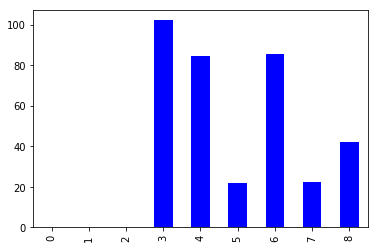

State points

|  | T | P | x | h | s | u | v | Qu |
| --- | --- | --- | --- | --- | --- | --- | --- | --- |
| rich_abs_outlet | 310 | 4.75071 | 0.508281 | -74.4766 | 0.391835 | -75.0599 | 0.00122787 | 0 |
| rich_pump_outlet | 310.093 | 10.6161 | 0.508281 | -73.5762 | 0.392416 | -74.8794 | 0.0012276 | -0.001 |
| rich_shx_outlet | 339.161 | 10.6161 | 0.508281 | 76.3836 | 0.851874 | 72.9667 | 0.00321857 | 0.0136051 |
| rich_gen_sat_liquid | 338.09 | 10.6161 | 0.508281 | 53.8805 | 0.785932 | 52.5292 | 0.00127282 | 0 |
| weak_gen_outlet | 380 | 10.6161 | 0.296492 | 278.322 | 1.35832 | 277.029 | 0.00121791 | 0 |
| weak_shx_outlet | 331.449 | 10.6161 | 0.296492 | 63.7467 | 0.754536 | 62.5309 | 0.00114525 | -0.001 |
| weak_exp_outlet | 331.554 | 4.75071 | 0.296492 | 63.7467 | 0.756563 | 63.2024 | 0.00114571 | -0.001 |
| gen_vapor_outlet | 338.09 | 10.6161 | 0.991505 | 1404.76 | 4.67404 | 1252.02 | 0.143873 | 1 |
| gen_reflux_inlet | 338.09 | 10.6161 | 0.508144 | 53.4903 | 0.784686 | 52.1388 | 0.00127304 | 0 |
| refrig_rect_outlet | 310 | 10.6161 | 0.9998 | 1319.41 | 4.40903 | 1183.88 | 0.127667 | 1.001 |
| refrig_cond_outlet | 300 | 10.6161 | 0.9998 | 126.371 | 0.449872 | 124.599 | 0.00166955 | 0 |
| refrig_cehx_liquid_outlet | 288.531 | 10.6161 | 0.9998 | 71.6979 | 0.264117 | 69.979 | 0.00161918 | -0.001 |
| refrig_exp_outlet | 275.888 | 4.75071 | 0.9998 | 71.6979 | 0.271305 | 65.1137 | 0.0138595 | 0.0470472 |
| refrig_evap_outlet | 278 | 4.75071 | 0.9998 | 1274.56 | 4.61607 | 1148.58 | 0.268136 | 0.998 |
| refrig_cehx_sat_vapor | 283.116 | 4.75071 | 0.9998 | 1277.44 | 4.62101 | 1151.16 | 0.265812 | 1 |
| refrig_cehx_vapor_outlet | 298.823 | 4.75071 | 0.9998 | 1329.23 | 4.80012 | 1190.99 | 0.291 | 1.001 |
| rectifier_liquid | 310 | 10.6161 | 0.754255 | 4.87593 | 0.474284 | 3.37182 | 0.00141683 | 0 |
| gen_vapor_formation | 380 | 10.6161 | 0.911714 | 1597.75 | 5.18047 | 1423.34 | 0.16429 | 1 |
| abs_vapor_final | 331.554 | 4.75071 | 0.980064 | 1429.36 | 5.11629 | 1273.54 | 0.327978 | 1 |

Performance variables

| name | unit | value |
| --- | --- | --- |
| Q_abs | kW | -207.721 |
| Q_gen | kW | 219.251 |
| Q_cond | kW | -143.705 |
| Q_evap | kW | 144.888 |
| Q_reflux | kW | -13.0737 |
| Q_shx | kW | 59.9839 |
| Q_cehx | kW | 6.58557 |
| W_pump | kW | 0.36015 |
| COP | kW/kW | 0.660831 |
| ZeroCheck | kW | -6.37487e-07 |
| ZeroCheckSHX | kW | 7.33205e-07 |
| ZeroCheckCEHX | kW | -3.53678e-09 |
| Q_gen_rect_combo | kW | 206.178 |
| Q_refrig_side | kW | -1.183 |
| ZeroCheckRect | kg/s | 0 |
| m_rich | kg/s | 0.4 |
| m_weak | kg/s | 0.279547 |
| m_gen_vapor | kg/s | 0.12252 |
| m_gen_reflux | kg/s | 0.00206711 |
| m_refrig | kg/s | 0.120453 |
| check_rectifier_delta_T | K | 28.09 |
| is_degenerate | bool | 0 |

```python
spec = makeSpec(T_abs=310)
a1 = AquaChillerSpec1(spec)
display(a1)
cons = a1.C
colors = cons.map(lambda c: 'b' if c > 0 else 'r')
b = cons.plot.bar(color="".join(colors.tolist()))
plt.show()
ch = ammonia1.AmmoniaChiller()
ch.update(x_refrig=spec.x_refrig, T_evap=spec.T_evap, T_cond=spec.T_cond,
          T_abs_outlet=spec.T_abs, T_gen_outlet=spec.T_gen, T_rect=spec.T_rect)
display(ch)
```

```python
'hello' == 'hello'
```

```
True
```

### Widget demonstration

```python
%matplotlib inline
import ipywidgets as widgets
import widgetsnbextension
from ipywidgets import interactive

import system_aqua1
import ammonia1

common_opts = dict(
    disabled=False,
    continuous_update=False,
    orientation='horizontal',
    readout=True
)
w_m_rich = widgets.FloatSlider(
    value=0.5,
    min=0.1,
    max=2.0,
    step=0.05,
    description='m_rich',
    readout_format='.2f',
    **common_opts
)
w_T_evap = widgets.FloatSlider(
    value=278.0,
    min=200.0,
    max=300.0,
    step=0.1,
    description='T_evap',
    readout_format='.1f',
    **common_opts
)
w_T_cond = widgets.FloatSlider(
    value= 312.2,
    min=200,
    max=400,
    step=0.1,
    description='T_cond',
    readout_format='.1f',
    **common_opts
)
w_T_rect = widgets.FloatSlider(
    value=313.7,
    min=200.0,
    max=400.0,
    step=0.1,
    description='T_rect',
    readout_format='.1f',
    **common_opts
)
w_T_abs_outlet = widgets.FloatSlider(
    value=310.2,
    min=200.0,
    max=400.0,
    step=0.1,
    description='T_abs_outlet',
    readout_format='.1f',
    **common_opts
)
w_T_gen_outlet = widgets.FloatSlider(
    value=374.1,
    min=200.0,
    max=500.0,
    step=0.1,
    description='T_gen_outlet',
    readout_format='.1f',
    **common_opts
)
w_x_refrig = widgets.FloatSlider(
    value = 0.998,
    min = 0.8,
    max = 1.1,
    step = 0.001,
    description='x_refrig',
    readout_format='.4f',
    **common_opts
)
def f(m_rich, T_evap, T_cond, T_rect, T_abs_outlet, T_gen_outlet, x_refrig):

    spec = makeSpec(T_abs_outlet, T_cond, T_evap, T_gen_outlet, T_rect, x_refrig)
    a1 = AquaChillerSpec1(spec)
    display(a1)
    colors = "".join(a1.C.map(lambda c: 'b' if c > 0 else 'r').tolist())
    a1.C.plot.bar(color=colors)
    plt.show()

    ch = ammonia1.AmmoniaChiller()
    try:
        ch.update(x_refrig=a1.mapped.x_refrig,
                  T_evap=a1.mapped.T_evap,
                  T_cond=a1.mapped.T_cond,
                  T_abs_outlet=a1.mapped.T_abs,
                  T_gen_outlet=a1.mapped.T_gen,
                  T_rect=a1.mapped.T_rect)
        display(ch)
    except:
        print("Couldn't create chiller")

#widgets.VBox(w_m_rich,w_T_evap,w_T_cond,w_T_rect,w_T_abs_outlet,w_T_gen_outlet)
interactive(f,
            m_rich=w_m_rich,
            T_evap=w_T_evap,
            T_cond=w_T_cond,
            T_rect=w_T_rect,
            T_abs_outlet=w_T_abs_outlet,
            T_gen_outlet=w_T_gen_outlet,
            x_refrig=w_x_refrig
           )
```

```python
a1.C[1]
```

```
0.0998
```

### Visualize feasible / infeasible regions

```python
list(range(AquaChillerSpec1.n_cons))
```

```
[0, 1, 2, 3, 4, 5, 6, 7, 8]
```

```python
# Parametric study / visualize infeasible regions
x_refrig_range = [0.998, 0.9998, 0.99998]
T_low_range = numpy.linspace(220, 420, 40) #40
T_med_range = numpy.linspace(220, 420, 40) #40
T_high_range = numpy.linspace(220, 600, 40) #40
shape = (len(x_refrig_range),len(T_low_range),len(T_med_range),len(T_high_range))
study_index = pandas.MultiIndex.from_product(
    [x_refrig_range,T_low_range,T_med_range,T_high_range],
    names=['x_refrig','T_low','T_med','T_high'])
study_columns=all_columns
```

```python
study = pandas.DataFrame(
    index=study_index,
    columns=study_columns)
print(shape, len(study))
study.head()
```

```
(3, 40, 40, 40) 192000
```

| x_refrig | T_low | T_med | T_high | spec T_abs | spec T_cond | spec T_evap | spec T_gen | spec T_rect | spec x_refrig | constraint 0 | constraint 1 | constraint 2 | constraint 3 | ... | calc x_rich_max | calc x_rich | calc T_abs_max2 | calc T_gen_min | mapped T_abs | mapped T_cond | mapped T_evap | mapped T_gen | mapped T_rect | mapped x_refrig |
| --- | --- | --- | --- | --- | --- | --- | --- | --- | --- | --- | --- | --- | --- | --- | --- | --- | --- | --- | --- | --- | --- | --- | --- | --- |
| 0.998 | 220.0 | 220.0 | 220.000000 | NaN | NaN | NaN | NaN | NaN | NaN | NaN | NaN | NaN | NaN | ... | NaN | NaN | NaN | NaN | NaN | NaN | NaN | NaN | NaN | NaN |
|  |  |  | 229.743590 | NaN | NaN | NaN | NaN | NaN | NaN | NaN | NaN | NaN | NaN | ... | NaN | NaN | NaN | NaN | NaN | NaN | NaN | NaN | NaN | NaN |
|  |  |  | 239.487179 | NaN | NaN | NaN | NaN | NaN | NaN | NaN | NaN | NaN | NaN | ... | NaN | NaN | NaN | NaN | NaN | NaN | NaN | NaN | NaN | NaN |
|  |  |  | 249.230769 | NaN | NaN | NaN | NaN | NaN | NaN | NaN | NaN | NaN | NaN | ... | NaN | NaN | NaN | NaN | NaN | NaN | NaN | NaN | NaN | NaN |
|  |  |  | 258.974359 | NaN | NaN | NaN | NaN | NaN | NaN | NaN | NaN | NaN | NaN | ... | NaN | NaN | NaN | NaN | NaN | NaN | NaN | NaN | NaN | NaN |

5 rows × 32 columns

```python
plt.hist(study['calc','P_cond'],bins=range(0,250,10),range=[0,25000])
plt.show()
```

[output not shown]

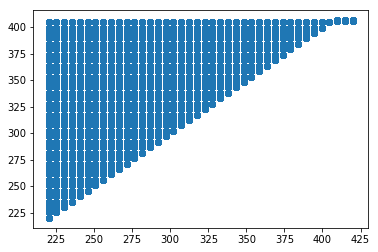

```python
#plt.scatter(study['spec','x_refrig'],study['mapped','x_refrig'])
#plt.scatter(study['spec','x_refrig'],study['calc','P_cond'])
plt.scatter(study['spec','T_cond'],study['mapped','T_cond'])
#plt.scatter(study['spec','T_cond'],study['calc','P_cond'])
plt.show()
```

```python
study.loc[0.998,:,:,:]['constraint']
```

[output not shown]

64000 rows × 9 columns

```python
study.index[129405]
```

```
(0.99997999999999998, 220.0, 399.4871794871795, 268.71794871794873)
```

```python
#https://github.com/alexanderkuk/log-progress
def log_progress(sequence, every=None, size=None, name='Items'):
    from ipywidgets import IntProgress, HTML, VBox
    from IPython.display import display

    is_iterator = False
    if size is None:
        try:
            size = len(sequence)
        except TypeError:
            is_iterator = True
    if size is not None:
        if every is None:
            if size <= 200:
                every = 1
            else:
                every = int(size / 200)     # every 0.5%
    else:
        assert every is not None, 'sequence is iterator, set every'

    if is_iterator:
        progress = IntProgress(min=0, max=1, value=1)
        progress.bar_style = 'info'
    else:
        progress = IntProgress(min=0, max=size, value=0)
    label = HTML()
    box = VBox(children=[label, progress])
    display(box)

    index = 0
    try:
        for index, record in enumerate(sequence, 1):
            if index == 1 or index % every == 0:
                if is_iterator:
                    label.value = '{name}: {index} / ?'.format(
                        name=name,
                        index=index
                    )
                else:
                    progress.value = index
                    label.value = u'{name}: {index} / {size}'.format(
                        name=name,
                        index=index,
                        size=size
                    )
            yield record
    except:
        progress.bar_style = 'danger'
        raise
    else:
        progress.bar_style = 'success'
        progress.value = index
        label.value = "{name}: {index}".format(
            name=name,
            index=str(index or '?')
        )
```

```python
study.iloc[0]['constraint',0]
```

```
nan
```

```python
study.iloc[0]['constraint','0']
```

[output not shown]

```python
%%time
for i in log_progress(range(len(study.index)), every=100):
    (x_refrig,T_low,T_med,T_high) = study.index[i]
    if numpy.isnan(study.iloc[i]['constraint',0]):
        spec = makeSpec(T_abs=T_med,T_cond=T_med,T_evap=T_low,T_gen=T_high, x_refrig=x_refrig)
        study.iloc[i]['spec'] = spec
        a1 = AquaChillerSpec1(spec)
        study.iloc[i]['constraint'] = a1.C
        study.iloc[i]['calc'] = a1.calc
        study.iloc[i]['mapped'] = a1.mapped
print("Done.")
#violations[violations>0] = numpy.nan
```

```
Done.
Wall time: 10h 3min 37s
```

```python
a1=AquaChillerSpec1(spec,False)
```

```python
a1
```

```
T_abs       420.00000
T_cond      420.00000
T_evap      420.00000
T_gen       600.00000
T_rect      310.00000
x_refrig      0.99998
dtype: float64
```

Computed limits

```
x_refrig_min           NaN
x_refrig_max           NaN
T_cond_max      384.620083
T_evap_min      177.547681
P_cond           80.002448
P_evap          176.503483
T_abs_max1      596.538905
x_rich_max        1.000000
x_rich            1.000000
T_abs_max2      419.827603
T_gen_min       384.617885
dtype: float64
```

Mapped inputs

```
T_abs       420.000000
T_cond      384.620083
T_evap      420.000000
T_gen       600.000000
T_rect      310.000000
x_refrig      0.999980
dtype: float64
```

Constraint functions

```
0      0.000000
1      0.099980
2      0.000020
3    242.452319
4    -35.379917
5      0.000000
6    176.538905
7     -0.172397
8    215.382115
dtype: float64
```

Warnings

- T_cond (420) should be less than 384.62 but is not.

- T_abs (420) should be less than 419.828 but is not.

```python
fname = 'feasibility_ammonia_data2.csv'
```

```python
study.to_csv(fname)
```

```python
import pandas
study= pandas.read_csv(fname, header=[0,1], index_col=[0,1,2,3])
```

```python
study.head()
```

| x_refrig | T_low | T_med | T_high | spec T_abs | spec T_cond | spec T_evap | spec T_gen | spec T_rect | spec x_refrig | constraint 0 | constraint 1 | constraint 2 | constraint 3 | ... | calc x_rich_max | calc x_rich | calc T_abs_max2 | calc T_gen_min | mapped T_abs | mapped T_cond | mapped T_evap | mapped T_gen | mapped T_rect | mapped x_refrig |
| --- | --- | --- | --- | --- | --- | --- | --- | --- | --- | --- | --- | --- | --- | --- | --- | --- | --- | --- | --- | --- | --- | --- | --- | --- |
| 0.998 | 220.0 | 220.0 | 220.000000 | 220 | 220 | 220 | 220 | 310 | 0.998 | 0 | 0.098 | 0.002 | 3.26264 | ... | 0.378578 | 0.378578 | 232.465 | 264.874 | 220 | 220 | 220 | 264.874 | 310 | 0.998 |
|  |  |  | 229.743590 | 220 | 220 | 220 | 229.744 | 310 | 0.998 | 0 | 0.098 | 0.002 | 3.26264 | ... | 0.378578 | 0.378578 | 232.465 | 264.874 | 220 | 220 | 220 | 264.874 | 310 | 0.998 |
|  |  |  | 239.487179 | 220 | 220 | 220 | 239.487 | 310 | 0.998 | 0 | 0.098 | 0.002 | 3.26264 | ... | 0.378578 | 0.378578 | 232.465 | 264.874 | 220 | 220 | 220 | 264.874 | 310 | 0.998 |
|  |  |  | 249.230769 | 220 | 220 | 220 | 249.231 | 310 | 0.998 | 0 | 0.098 | 0.002 | 3.26264 | ... | 0.378578 | 0.378578 | 232.465 | 264.874 | 220 | 220 | 220 | 264.874 | 310 | 0.998 |
|  |  |  | 258.974359 | 220 | 220 | 220 | 258.974 | 310 | 0.998 | 0 | 0.098 | 0.002 | 3.26264 | ... | 0.378578 | 0.378578 | 232.465 | 264.874 | 220 | 220 | 220 | 264.874 | 310 | 0.998 |

5 rows × 32 columns

```python
constraints=study['constraint']
okay = constraints >= 0
okay.head()
```

| x_refrig | T_low | T_med | T_high | 0 | 1 | 2 | 3 | 4 | 5 | 6 | 7 | 8 |
| --- | --- | --- | --- | --- | --- | --- | --- | --- | --- | --- | --- | --- |
| 0.998 | 220.0 | 220.0 | 220.000000 | True | True | True | True | True | True | True | True | False |
|  |  |  | 229.743590 | True | True | True | True | True | True | True | True | False |
|  |  |  | 239.487179 | True | True | True | True | True | True | True | True | False |
|  |  |  | 249.230769 | True | True | True | True | True | True | True | True | False |
|  |  |  | 258.974359 | True | True | True | True | True | True | True | True | False |

```python
okay.all(axis='columns').head()
```

```
x_refrig  T_low  T_med  T_high
0.998     220.0  220.0  220.000000    False
                        229.743590    False
                        239.487179    False
                        249.230769    False
                        258.974359    False
dtype: bool
```

```python
penalty = -constraints.min(axis='columns')
penalty.head()
#penalty.values.reshape(shape)[3,:,:]
```

```
x_refrig  T_low  T_med  T_high
0.998     220.0  220.0  220.000000    44.874290
                        229.743590    35.130700
                        239.487179    25.387110
                        249.230769    15.643521
                        258.974359     5.899931
dtype: float64
```

```python
worst = constraints.idxmin(axis='columns').astype('float')
worst.head()
```

```
x_refrig  T_low  T_med  T_high
0.998     220.0  220.0  220.000000    8.0
                        229.743590    8.0
                        239.487179    8.0
                        249.230769    8.0
                        258.974359    8.0
dtype: float64
```

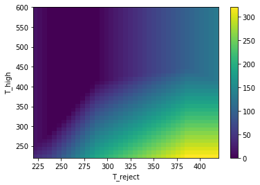

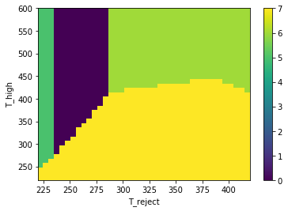

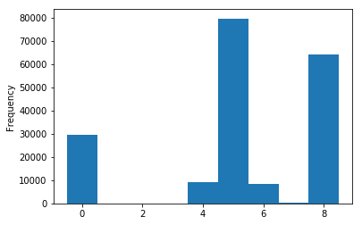

```python
plt.figure()
#plt.contourf(T_med_range, T_high_range, violations.T, cmap='spring')
plt.pcolormesh(T_med_range, T_high_range, penalty.values.reshape(shape)[0,3,:,:].T) #, cmap='spring')
plt.xlabel("T_reject")
plt.ylabel("T_high")
plt.colorbar()

plt.figure()
#plt.imshow(worst[:,::-1].T)
plt.pcolormesh(T_med_range,T_high_range,worst.values.reshape(shape)[0,3,:,:].T,vmin=0.,vmax=7.)
#plt.contourf(T_med_range, T_high_range, worst.T, cmap='Pastel1', vmin=0, vmax=255 )
plt.xlabel("T_reject")
plt.ylabel("T_high")
plt.colorbar()

plt.figure()
worst.plot.hist(bins=numpy.arange(-0.5,AquaChillerSpec1.n_cons))

plt.show()
```

```python
import pyvtk
for j,x_refrig in enumerate(x_refrig_range):
    fname = 'feasibility_ammonia_data2.{}.vtk'.format(j)
    grid = pyvtk.RectilinearGrid(T_high_range,T_med_range,T_low_range)
    vtk = pyvtk.VtkData(grid)
    vtk.point_data.append(pyvtk.Scalars(penalty.loc[x_refrig,:,:,:].values,
                                        name='Cost penalty'))
    for i in range(AquaChillerSpec1.n_cons):
        vtk.point_data.append(pyvtk.Scalars(constraints.loc[x_refrig,:,:,:][i].values,
                                            name='C{}'.format(i)))
    vtk.point_data.append(pyvtk.Scalars(worst.loc[x_refrig,:,:,:].values,
                                        name='Worst constraint'))
    vtk.tofile(fname)
```

```python
x_refrig_range
```

```
[0.998, 0.9998, 0.99998]
```

### Problem cases

```python
# Problem cases ... should work but don't. Wow.
for T_med in [396.666667]:
    print(amm.props2(T=T_med,x=0.9998,Qu=0.000001))
for T_med in [396.666666,396.666668,396.666667]:
    print(amm.props2(T=T_med,x=0.9998,Qu=0.00000))
```

```
State(T=396.666667, P=102.11911867081996, x=0.9998, h=655.3371030500907, s=1.9179410016989382, u=632.079587356763, v=0.0022774442432729365, Qu=1e-06)
State(T=396.666666, P=130.71246947558606, x=0.9998, h=652.5895375913475, s=1.8947393278504907, u=622.8633116836049, v=0.0022748701284714405, Qu=0.0)
State(T=396.666668, P=102.05594348386495, x=0.9998, h=655.2895597768476, s=1.918085931480245, u=632.0484545407089, v=0.0022772893899859624, Qu=0.0)
```

```
---------------------------------------------------------------------------
KeyError                                  Traceback (most recent call last)
<ipython-input-3-2f49da9b80de> in <module>()
      3     print(amm.props2(T=T_med,x=0.9998,Qu=0.000001))
      4 for T_med in [396.666666,396.666668,396.666667]:
----> 5     print(amm.props2(T=T_med,x=0.9998,Qu=0.00000))

~\Documents\GitHub\openACHP\src\ammonia_props.py in props2(self, **kwargs)
    221         if s:
    222             #print(vals)
--> 223             raise KeyError('DLL returned {}'.format(s))
    224
    225         if out:

KeyError: "DLL returned b'Saturation properties cannot be determined for the given input variables'"
```

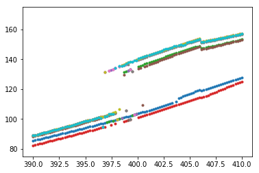

```python
#T=numpy.linspace(350,500,100)
T=numpy.linspace(390,410,100)
P0=T.copy(); P0.fill(nan)
P1=P0.copy()
for x in [0.98, 0.998, 0.9998, 0.99998, 0.999998]:
    for i,t in enumerate(T):
        try:
            P0[i]=amm.props2(T=t,x=x,Qu=0,out='P')
            P1[i]=amm.props2(T=t,x=x,Qu=1,out='P')
        except:
            pass
    plt.plot(T,P0,'.')
    plt.plot(T,P1,'.')
plt.ylim(75,175)
plt.show()
```

## Appendix

### Visualize relations between a few variables of state

```python
import CoolProp
import CoolProp.CoolProp as CP
import numpy
from numpy import array, inf, nan
import matplotlib.pyplot as plt
T0, x0, Qu0 = 350., 0.8, 1.0
P0 = CP.PropsSI('P','T',T0,'Q',Qu0,"REFPROP::ammonia[{}]&water[{}]".format(x0,1.-x0))
```

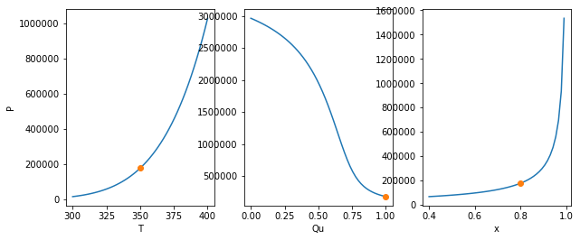

```python
T = numpy.linspace(300,400)
Qu = numpy.linspace(0,1)
x = numpy.linspace(0.4,0.99)

plt.close('all')
fig = plt.figure(figsize=[10,4])

#CP.PropsSI('P','T',350, 'Q',1,"REFPROP::ammonia[0.1]&water[0.9]")
P_vs_T = CP.PropsSI('P','T',T,'Q',Qu0,"REFPROP::ammonia[{}]&water[{}]".format(x0,1.-x0))
fig.add_subplot(131)
plt.plot(T, P_vs_T)
plt.plot(T0, P0, 'o')
plt.xlabel('T')
plt.ylabel('P')

P_vs_Qu = CP.PropsSI('P','T',T0,'Q',Qu,"REFPROP::ammonia[{}]&water[{}]".format(x0,1.-x0))
fig.add_subplot(132)
plt.plot(Qu, P_vs_Qu)
plt.plot(Qu0, P0, 'o')
plt.xlabel('Qu')

P_vs_x = array([CP.PropsSI('P','T',T0,'Q',Qu0,"REFPROP::ammonia[{}]&water[{}]".format(xi,1.-xi))
                for xi in x])
fig.add_subplot(133)
plt.plot(x, P_vs_x)
plt.plot(x0, P0, 'o')
plt.xlabel('x')

plt.show()
```

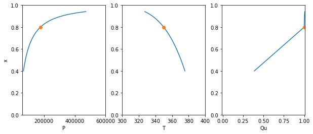

```python
qt5 = False
if qt5:
    %matplotlib qt5
else:
    %matplotlib inline
plt.close('all')
fig = plt.figure(figsize=[10,4])
ax1=fig.add_subplot(131)
ax1.set_ylim(0,1)
ax1.set_xlim(6e4, 6e5)
ax1.set_ylabel('x')
ax1.set_xlabel('P')

ax2=fig.add_subplot(132)
ax2.set_ylim(0,1)
ax2.set_xlim(3e2, 4e2)
ax2.set_xlabel('T')

ax3=fig.add_subplot(133)
ax3.set_ylim(0,1)
ax3.set_xlim(-1e-2, 1+1e-2)
ax3.set_xlabel('Qu')

if qt5:
    ax1.plot(P0, x0, 'o')
    ax2.plot(T0, x0, 'o')
    ax3.plot(Qu0, x0, 'o')

pointopts = dict(color='grey', alpha=0.5, markersize=5.)

CPRP = CoolProp.AbstractState("REFPROP","ammonia&water")
PTQ = numpy.empty([3,len(x)])
PTQ.fill(nan)
try:
    for i,xi in enumerate(x):
        #print("Case", i, flush=True)
        if i > 45:
            continue
        CPRP.set_mole_fractions([xi,1-xi])
        try:
            CPRP.update(CoolProp.QT_INPUTS,Qu0,T0)
            pi = CPRP.p()
        except ValueError:
            pi = nan

        try:
            CPRP.update(CoolProp.PQ_INPUTS,P0,Qu0)
            ti = CPRP.T()
        except ValueError:
            ti = nan

        try:
            CPRP.update(CoolProp.PT_INPUTS,P0,T0)
            qi = CPRP.Q()
        except ValueError:
            qi = nan
        if qt5:
            ax1.plot(pi, xi, 'o', **pointopts)
            ax2.plot(ti, xi, 'o', **pointopts)
            ax3.plot(qi, xi, 'o', **pointopts)
            fig.canvas.draw()
            fig.canvas.flush_events()
        else:
            PTQ[:,i] = pi, ti, qi
except:
    pass

if not qt5:
    ax1.plot(PTQ[0,:], x)
    ax2.plot(PTQ[1,:], x)
    ax3.plot(PTQ[2,:], x)
    ax1.plot(P0, x0, 'o')
    ax2.plot(T0, x0, 'o')
    ax3.plot(Qu0, x0, 'o')

    plt.show()
```

```python
# Absorber "Good case": P_evap is greater than the equilibrium P0; quality is lower than 1.
P_evap = P0 * 1.1
Qu_imagined = CP.PropsSI('Q','T',T0,'P',P_evap,"REFPROP::ammonia[{}]&water[{}]".format(x0,1.-x0))
Qu_imagined
```

```
0.9675526740934721
```

```python
# Absorber "Bad case": P_evap is less than the equilibrium P0; quality is greater than 1.
P_evap = P0 * 0.9
Qu_imagined = CP.PropsSI('Q','T',T0,'P',P_evap,"REFPROP::ammonia[{}]&water[{}]".format(x0,1.-x0))
Qu_imagined
```

```
1.0005894260535513
```

### Evaporator vapor quality effect on operating pressure and maximum solution rich mass fraction

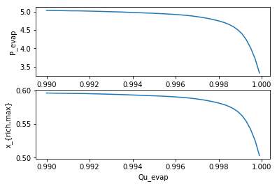

```python
# What is the effect of vapor quality at evaporator outlet?
Qu_evap = numpy.linspace(0.99,0.9999)
T,P_evap,x,h,s,u,v,Qu=amm.props2v(T=278,x=0.9998,Qu=Qu_evap)
T,P,x_abs,h,s,u,v,Qu=amm.props2v(T=300,P=P,Qu=0)

fig=plt.figure()
ax1=fig.add_subplot(211)
ax1.set_ylabel('P_evap')
ax1.plot(Qu_evap,P_evap)

ax2=fig.add_subplot(212)
ax2.set_ylabel('x_{rich,max}')
ax2.set_xlabel('Qu_evap')
ax2.plot(Qu_evap,x_abs)
plt.show()
```

```python
%%html
<textarea id="TOC-markdown" style="font-family:monospace;width:80%;height:20em;">TOC will be here</textarea>
<script>
$("#TOC-markdown").html(
    $('h1,h2,h3,h4').filter(":has(a)").map(function(){
        return "  ".repeat($(this).prop("tagName")[1])
          + "- <a href='" + encodeURI($(this).children().attr("href")) + "'>"
          + $(this).text() + "</a>";}).get().join("\n")
    );
</script>
```